# Survey Results: Support for Drone Data Collection on the RECs

Andy Lyons, Sean Hogan & Shane Feirer

REC Directors Meeting January 30, 2020

[figure not shown]

http://is.gd/recs_uas

# Background

In January 2020, IGIS conducted a survey of REC Directors to assess:

- the amount and type of drone data collection currently taking place on RECs
- aspirations for building capacity in supervising / supporting / conducting drone data collection
- the types of support that would best address the needs

# Have there been drone flights on your center in the last couple years?

yes (8)

# If yes, what were the goal(s)?

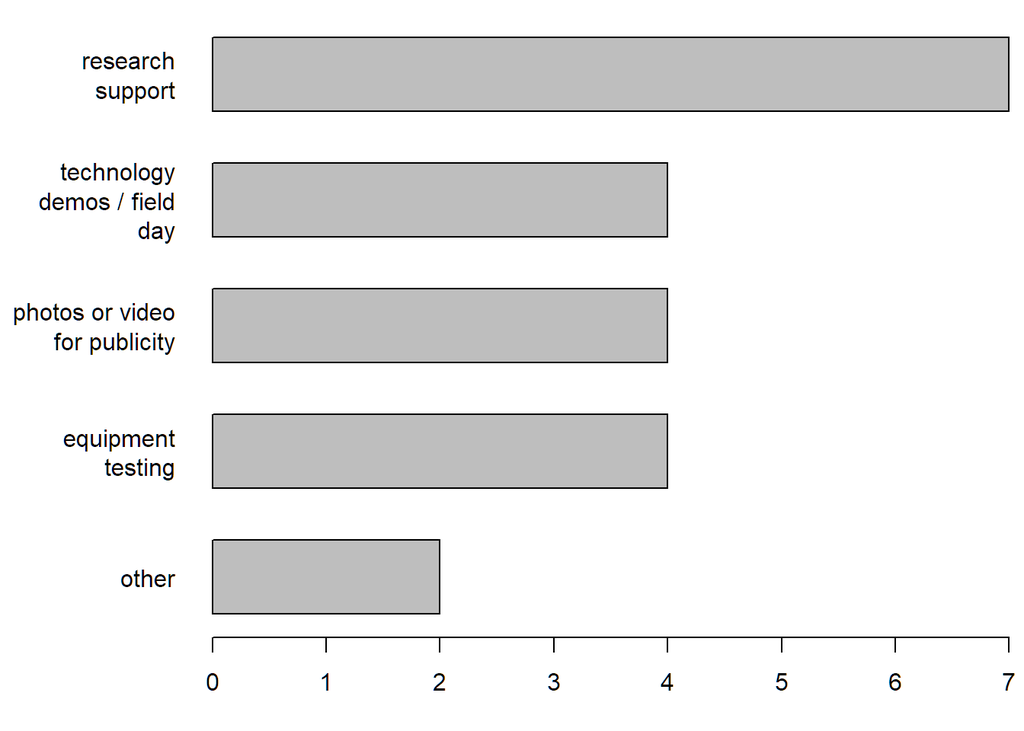

# If yes, who did the flights and processed the data?

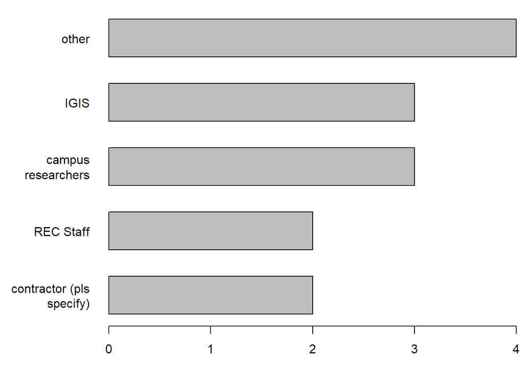

# Drone operators - details

“Part of various research programs.”

“Was for movie Call of the wild”

“(1) private company (Blue River) in association with a research trial; and (2) researcher Dan Putnam”

“Shane Feirer, based at HREC, did extensive drone mapping for research, and for outreach materials.”

“Research Cooperators”

# Relative to everything else, how valuable would it be for your Center to have in-house capacity to collect and/or process drone data?

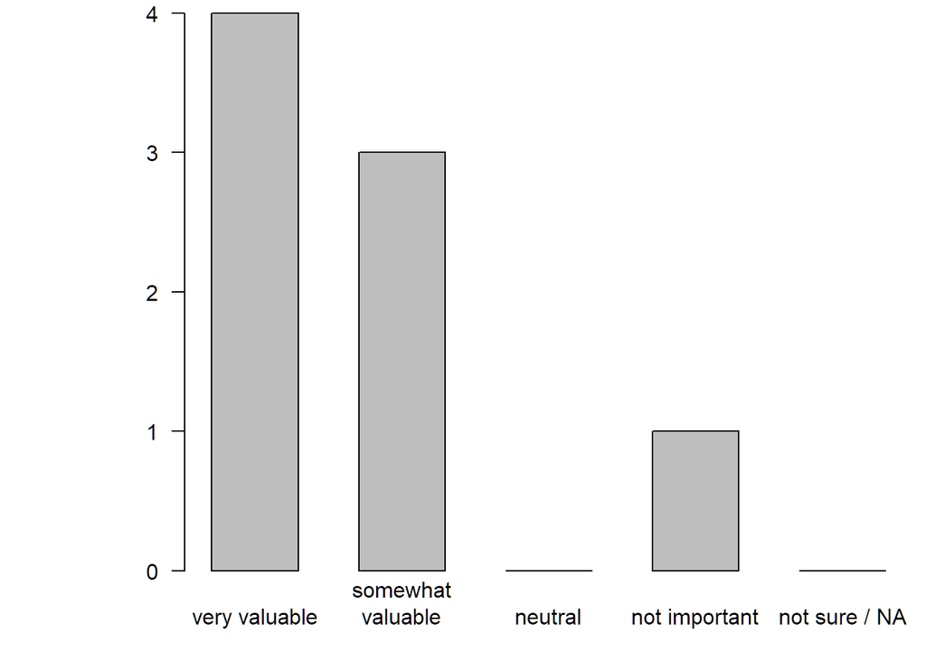

# Please rank the capabilities you would like to develop at your Center.

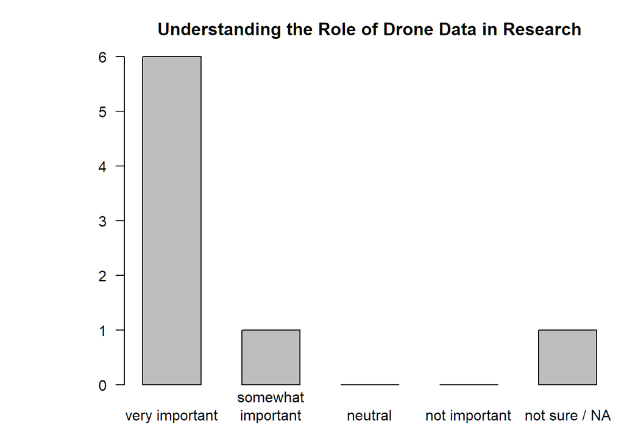

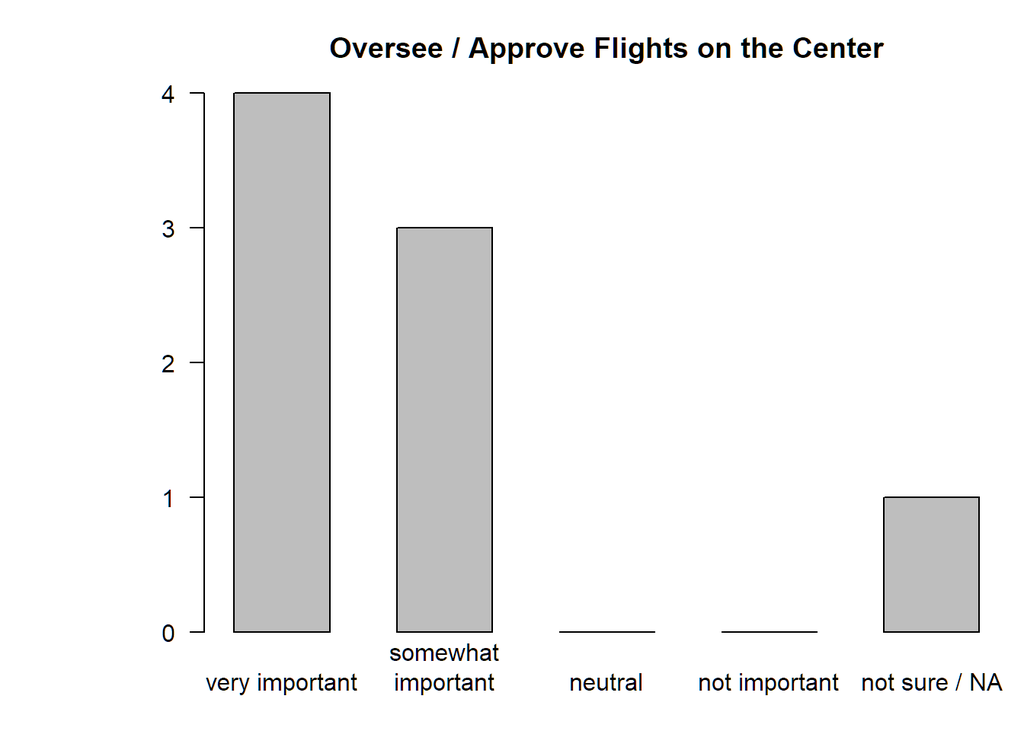

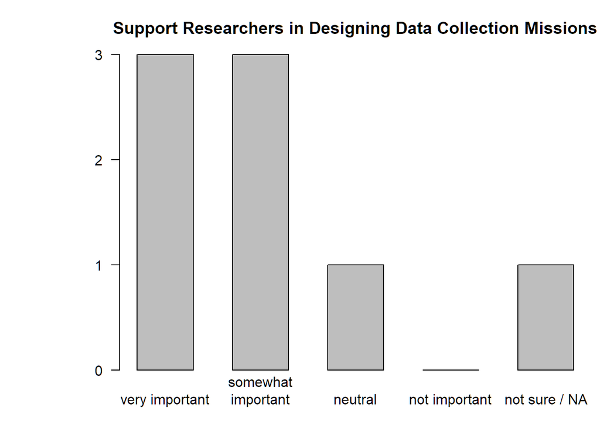

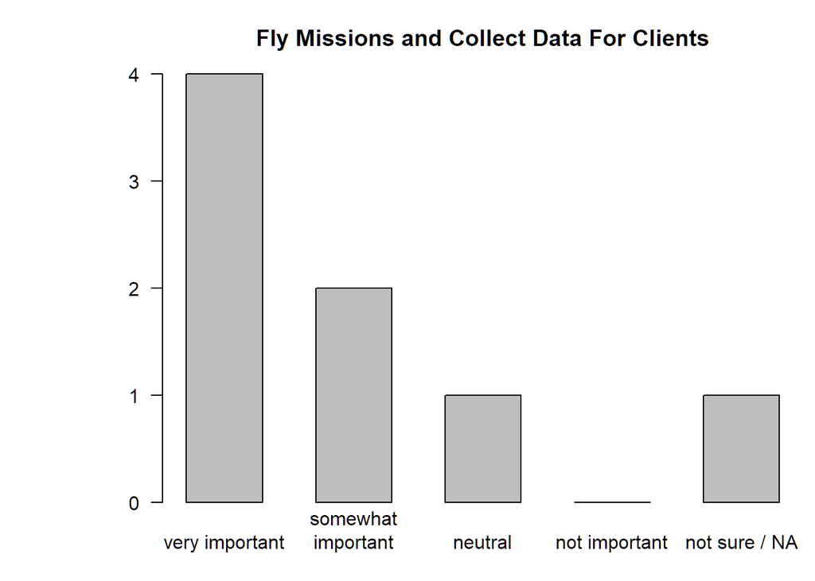

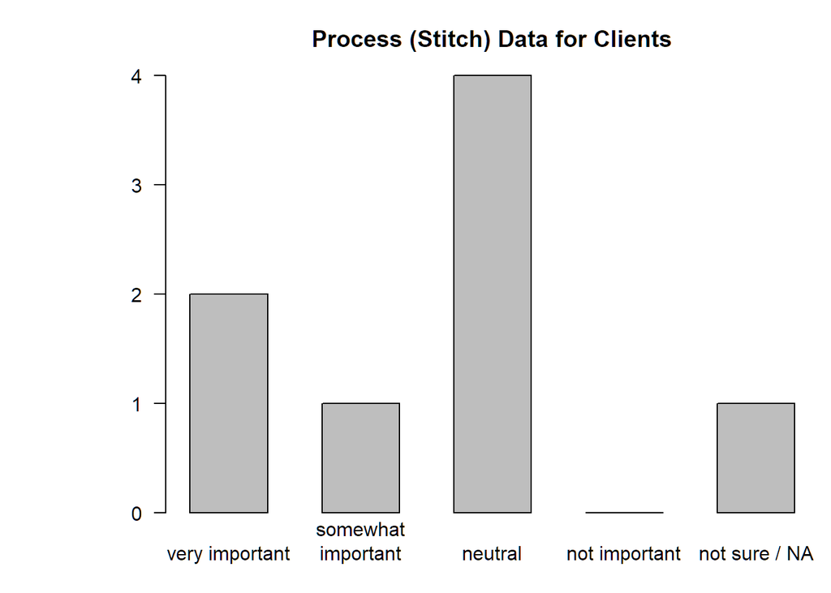

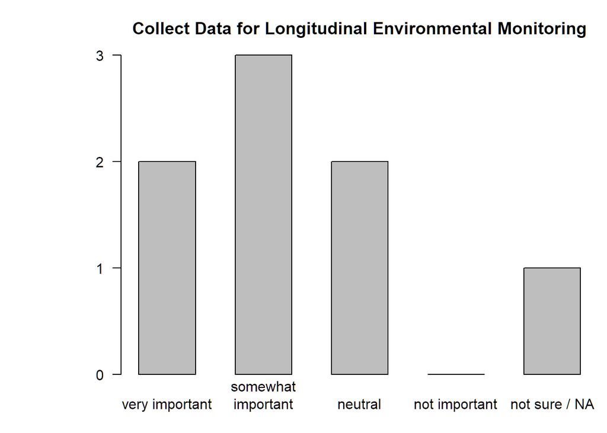

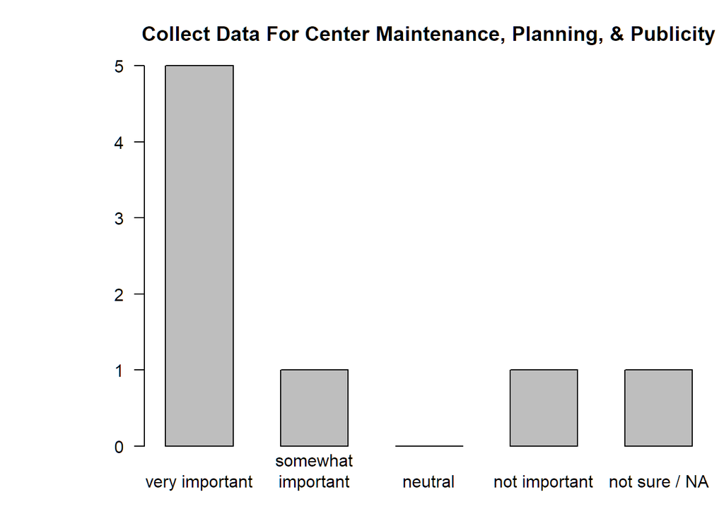

# Comments

“This sounds like a dedicate staff or person to be able to handle this and I think would be costly”

# What are your current in-house assets for drone data collection?

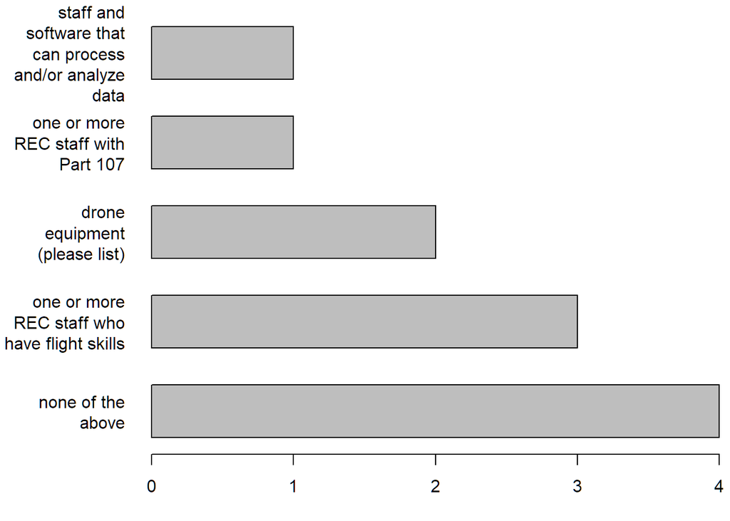

# Details

“HREC staff do not have these capabilities or equipment. However IGIS is onsite and very helpful.”

“IREC has a mavic pro and matrice 100”

# Please rank the following types of training and support.

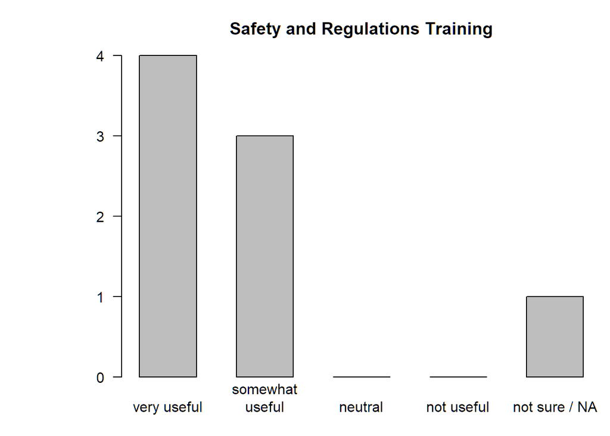

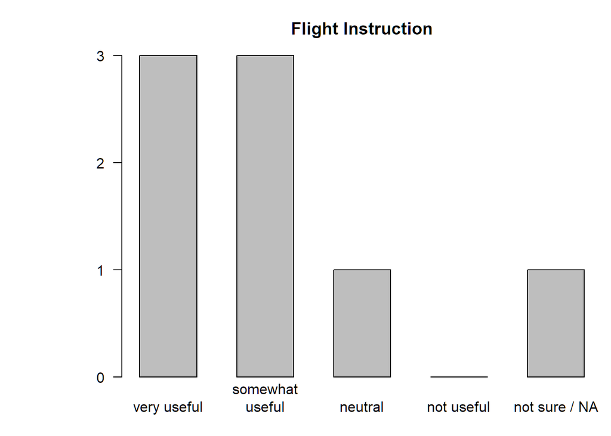

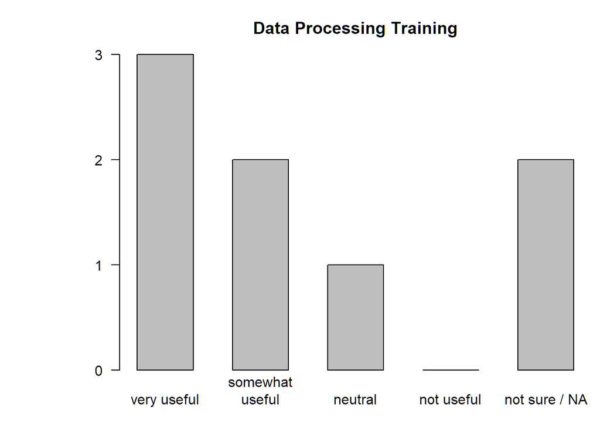

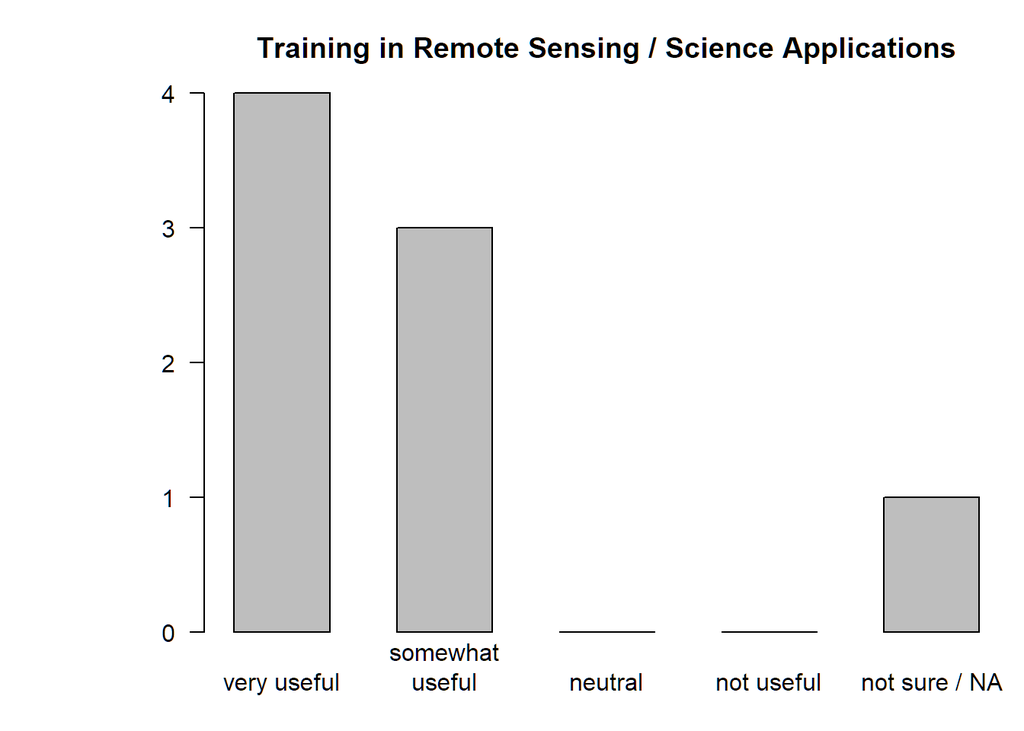

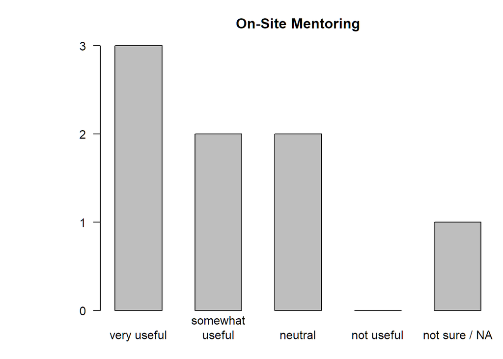

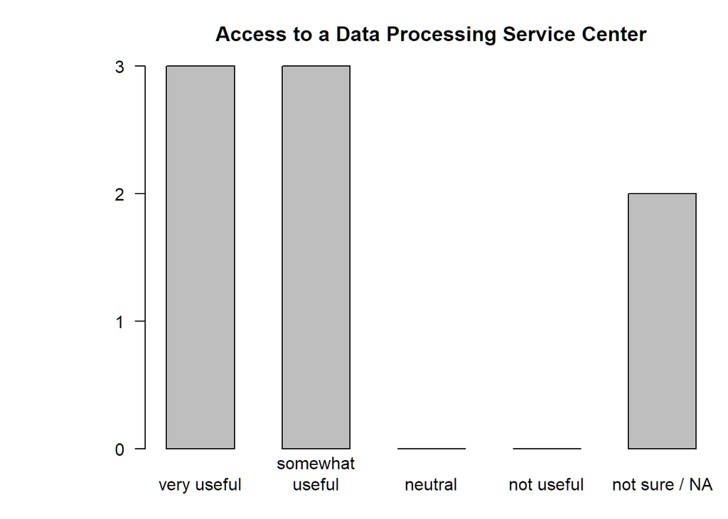

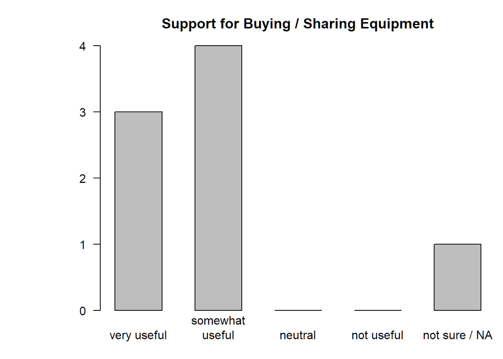

# What are the main barrier(s) to developing drone capacity on your center?

“We do not have the available FTE with our budget cuts to even support current center needs”

“Cost is the limiting factor and expertise. Flying the drone and gathering data is now fairly routine, ground truthing and analyzing the data are much more complicated and require good analytical and computer hardware.”

“Center too small, not enough staff available to train or develop capacity.”

“available personnel with adequate background and opportunities for training”

“The expense of getting the equipment. The time commitment with limited staffing and many other tasks.”

“I don’t see any barriers at this time.”

“Staff time dedicated to learning and providing this service to researchers.”

“Adequate demand from IREC researchers to pay recharge fees for drone flights, drone maintenance, and data processing/storage.”

# Other thoughts and suggestions?

“Having IGIS here at HREC is highly valuable and I want to ensure we can keep them here.”

“Right now, most people are contracting out, as this seems to be the most reasonable thing to do. Having support like this would take a rather large economic investment on ANR’s part to make it useful.”

“Very great ideas, this could be really useful and some centers may have the FTE available to do this”

“We currently have Researchers at LREC that have expressed an interest in collecting data with Drones”

“With the very small staff that we have at West Side REC, and no current SRA level employees, my thoughts are that it is unlikely that we could develop these capabilities unless we figure out a way to share an SRA level person with a researcher or researchers with projects at the Center. If we could find someone with ability and interest in being trained, there could be advantages to both the researchers and the Center.”

“Would like to be able to share with larger center, such as Southcoast or Lindcove; maybe develop regional capacity?”

# Summary & Conclusions

- all RECs have entered the ‘drone age’
- applications and goals for drone data are varied
- centers have different levels of capacity, resources, and aspirations
- staff and equipment are common barriers
- it’s not just about flying drones!
- no one-size-fit-all